# STAT 6340 Mini Project 4

# 1(c)

Using gpa~act, we fit a SLR. We show the least square estimates, standard  
errors and a 95% CI. We include verifications of our model assumptions

```r
fit = lm(gpa~act, data = gpa)
# least square estimate of coefficients, SE, and 95% CI
summary(fit)
```

```
##
## Call:
## lm(formula = gpa ~ act, data = gpa)
##
## Residuals:
##      Min       1Q   Median       3Q      Max
## -2.74004 -0.33827  0.04062  0.44064  1.22737
##
## Coefficients:
##             Estimate Std. Error t value Pr(>|t|)
## (Intercept)  2.11405    0.32089   6.588  1.3e-09 ***
## act          0.03883    0.01277   3.040  0.00292 **
## ---
## Signif. codes:  0 '***' 0.001 '**' 0.01 '*' 0.05 '.' 0.1 ' ' 1
##
## Residual standard error: 0.6231 on 118 degrees of freedom
## Multiple R-squared:  0.07262,    Adjusted R-squared:  0.06476
## F-statistic:  9.24 on 1 and 118 DF,  p-value: 0.002917
```

```r
confint(fit)
```

```
##                  2.5 %     97.5 %
## (Intercept) 1.47859015 2.74950842
## act         0.01353307 0.06412118
```

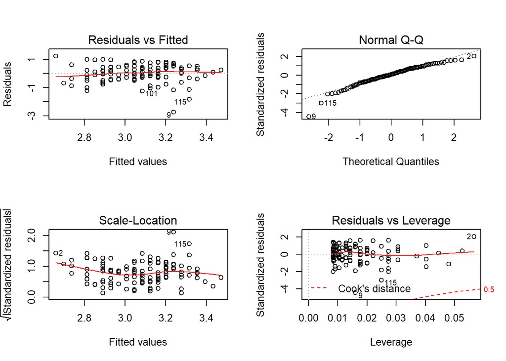

```r
par(mfrow = c(2,2))
plot(fit)
```

```r
par(mfrow = c(1,1))
# it appears the residual plot could do better via a transformation but not bad
# the qq plot is not bad but does show some outliers.
```

# 1(d)

```r
library(boot)
# function to output coefficients from linear model
fit.fn <- function(data, index) {
  result <- coef(lm(gpa ~ act , data = gpa, subset = index))
  return(result)
}
set.seed(1)
fit.boot = boot(gpa, fit.fn, R = 1000)
fit.boot
```

```
##
## ORDINARY NONPARAMETRIC BOOTSTRAP
##
##
## Call:
## boot(data = gpa, statistic = fit.fn, R = 1000)
##
##
## Bootstrap Statistics :
##       original        bias    std. error
## t1* 2.11404929 -0.0108361368  0.35962727
## t2* 0.03882713  0.0004350197  0.01455027
```

```r
boot.ci(fit.boot, type = "perc", index = 1) # intercept
```

```
## BOOTSTRAP CONFIDENCE INTERVAL CALCULATIONS
## Based on 1000 bootstrap replicates
##
## CALL :
## boot.ci(boot.out = fit.boot, type = "perc", index = 1)
##
## Intervals :
## Level     Percentile
## 95%   ( 1.387,  2.812 )
## Calculations and Intervals on Original Scale
```

```r
boot.ci(fit.boot, type = "perc", index = 2) # act
```

```
## BOOTSTRAP CONFIDENCE INTERVAL CALCULATIONS
## Based on 1000 bootstrap replicates
##
## CALL :
## boot.ci(boot.out = fit.boot, type = "perc", index = 2)
##
## Intervals :
## Level     Percentile
## 95%   ( 0.0110,  0.0674 )
## Calculations and Intervals on Original Scale
```

# Question 2(a)

We want to examine StoreID, STORE and Store7 variables form the OJ data.  
After a short EDA we determine that StoreID seems to contain all the info  
in STORE and Store7. Thus, we can drop STORE and Store7.  
We then use Purchase as our response, take StoreID as categorical, and split  
our data into a train set and test set for training and predicting

```r
library(ISLR)
names(OJ)
```

```
##  [1] "Purchase"       "WeekofPurchase" "StoreID"        "PriceCH"
##  [5] "PriceMM"        "DiscCH"         "DiscMM"         "SpecialCH"
##  [9] "SpecialMM"      "LoyalCH"        "SalePriceMM"    "SalePriceCH"
## [13] "PriceDiff"      "Store7"         "PctDiscMM"      "PctDiscCH"
## [17] "ListPriceDiff"  "STORE"
```

```r
# use only these 4 variables
OJ = subset(OJ, select = c(Purchase, StoreID, Store7, STORE))
str(OJ)
```

```
## 'data.frame':    1070 obs. of  4 variables:
##  $ Purchase: Factor w/ 2 levels "CH","MM": 1 1 1 2 1 1 1 1 1 1 ...
##  $ StoreID : num  1 1 1 1 7 7 7 7 7 7 ...
##  $ Store7  : Factor w/ 2 levels "No","Yes": 1 1 1 1 2 2 2 2 2 2 ...
##  $ STORE   : num  1 1 1 1 0 0 0 0 0 0 ...
```

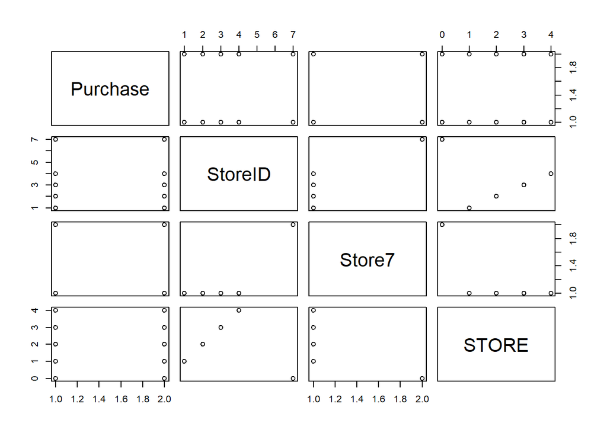

```r
# STORE is a subset of StoreID and Store7 is transitive through StoreID
pairs(OJ)
```

```r
fit = glm(Purchase~., family = binomial, data = OJ)
summary(fit)
```

```
##
## Call:
## glm(formula = Purchase ~ ., family = binomial, data = OJ)
##
## Deviance Residuals:
##     Min       1Q   Median       3Q      Max
## -1.2736  -0.9733  -0.7236   1.1852   1.7136
##
## Coefficients: (1 not defined because of singularities)
##             Estimate Std. Error z value Pr(>|z|)
## (Intercept)  0.46471    0.19347   2.402   0.0163 *
## StoreID     -0.24147    0.07339  -3.290   0.0010 **
## Store7Yes    0.01916    0.36632   0.052   0.9583
## STORE             NA         NA      NA       NA
## ---
## Signif. codes:  0 '***' 0.001 '**' 0.01 '*' 0.05 '.' 0.1 ' ' 1
##
## (Dispersion parameter for binomial family taken to be 1)
##
##     Null deviance: 1430.9  on 1069  degrees of freedom
## Residual deviance: 1360.4  on 1067  degrees of freedom
## AIC: 1366.4
##
## Number of Fisher Scoring iterations: 4
```

```r
rm(OJ)
# It appears that only StoreID and factor level "No" (intercept) from
# Store7 have any significance when all predictors are used.
# we drop Store7 and STORE
newOJ = subset(OJ, select = c(-Store7, -STORE))
# I do not see any reason to force MM = 1 and CH = 0
# When I experimented, I was able to produce the same results
newOJ$StoreID = as.factor(newOJ$StoreID) # take StoreID as factor
# str(newOJ) # uncomment to verify is factor
# split data 50/50, train/test
set.seed(1)
n = nrow(newOJ)
sampler = sample(1:n, n/2) # n/2 is the 50/50 splitter
train = newOJ[sampler, ]
test = newOJ[-sampler, ]
```

# 2(b)

Here we train a logisitc regression model and use the confusion matrix  
to obtain sensitivity, specificity, overall misclassification, then  
plot the ROC curve and estimate using a 10 fold cross validation  
The caret package does all of this nicely and compactly, so we proceed  
through the next few questions using similar coding.  
The accuracy from our model (train data) has accuracy (1-test error)  
very close to our confusion matrix accuracy (test data, predicted)  
The ROC curve has a nice left corner shape, notice that the graph  
continues to the left til -0.5, needs to be fixed to origin preferably (sorry!)  
pROC shapes it this way with asp = 1 to keep the shape square

```r
# 10 fold cv
  # library(crossval) # could not make sense of its inner workings
  # Even their examples needed tailoring, and even after that
  # it was not very intuitive.  I instead proceed with Caret package.
  # When using K-fold CV, we use the original data set unsplit.
  # However, I split the data beforehand so I could make a predict set
  # with the test data.  But in general this package's function should
  # do its own K splits as it trains/tests on the data.
  # A rather robust way of estimating accuracy (or test error rate)
library(caret)
set.seed(1)
tc <- trainControl(method = "cv", number = 10, verboseIter = F)
model <- train(Purchase~., train,
               method="glm", family="binomial", trControl = tc)
model
```

```
## Generalized Linear Model
##
## 535 samples
##  15 predictor
##   2 classes: 'CH', 'MM'
##
## No pre-processing
## Resampling: Cross-Validated (10 fold)
## Summary of sample sizes: 481, 482, 481, 481, 482, 482, ...
## Resampling results:
##
##   Accuracy   Kappa
##   0.8204403  0.6202817
```

```r
# 10-fold CV estimated test error rate = 1 - overall misclassification
# also, this is 1 - accuracy = test error rate (estimated)
glm.err = 1 - model$results[,2]
prob = predict(model, test, type = "prob")
# pred = predict(model, test) # or
pred <- ifelse(prob$MM >= 0.5, "MM", "CH")
con.mat = table(test[, "Purchase"], pred)
confusionMatrix(con.mat)
```

```
## Confusion Matrix and Statistics
##
##     pred
##       CH  MM
##   CH 287  43
##   MM  53 152
##
##                Accuracy : 0.8206
##                  95% CI : (0.7854, 0.8522)
##     No Information Rate : 0.6355
##     P-Value [Acc > NIR] : <2e-16
##
##                   Kappa : 0.6169
##  Mcnemar's Test P-Value : 0.3583
##
##             Sensitivity : 0.8441
##             Specificity : 0.7795
##          Pos Pred Value : 0.8697
##          Neg Pred Value : 0.7415
##              Prevalence : 0.6355
##          Detection Rate : 0.5364
##    Detection Prevalence : 0.6168
##       Balanced Accuracy : 0.8118
##
##        'Positive' Class : CH
##
```

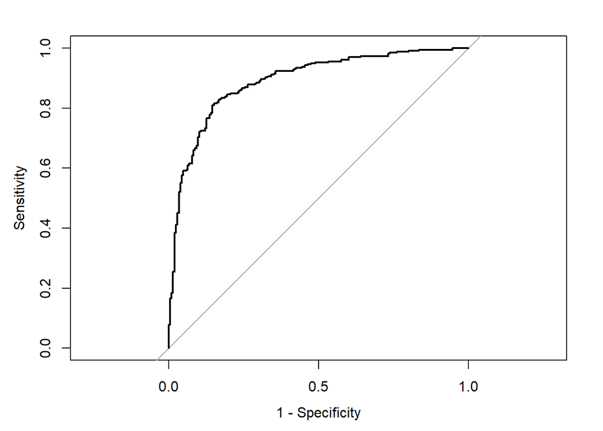

```r
library(pROC)
roc <- roc(test[, "Purchase"], prob$MM, levels = c("MM","CH"))
plot(roc, legacy.axes = T)
```

# 2(c)

We employ the same methods but using LDA instead

```r
library(caret)
set.seed(1)
model <- train(Purchase~., train,
               method="lda", trControl = tc)
model
```

```
## Linear Discriminant Analysis
##
## 535 samples
##  15 predictor
##   2 classes: 'CH', 'MM'
##
## No pre-processing
## Resampling: Cross-Validated (10 fold)
## Summary of sample sizes: 481, 482, 481, 481, 482, 482, ...
## Resampling results:
##
##   Accuracy   Kappa
##   0.8205101  0.6215449
```

```r
lda.err = 1 - model$results[,2]
prob = predict(model, test, type = "prob")
pred <- ifelse(prob$MM >= 0.5, "MM", "CH")
confusionMatrix(table(test$Purchase, pred))
```

```
## Confusion Matrix and Statistics
##
##     pred
##       CH  MM
##   CH 285  45
##   MM  52 153
##
##                Accuracy : 0.8187
##                  95% CI : (0.7834, 0.8504)
##     No Information Rate : 0.6299
##     P-Value [Acc > NIR] : <2e-16
##
##                   Kappa : 0.6139
##  Mcnemar's Test P-Value : 0.5424
##
##             Sensitivity : 0.8457
##             Specificity : 0.7727
##          Pos Pred Value : 0.8636
##          Neg Pred Value : 0.7463
##              Prevalence : 0.6299
##          Detection Rate : 0.5327
##    Detection Prevalence : 0.6168
##       Balanced Accuracy : 0.8092
##
##        'Positive' Class : CH
##
```

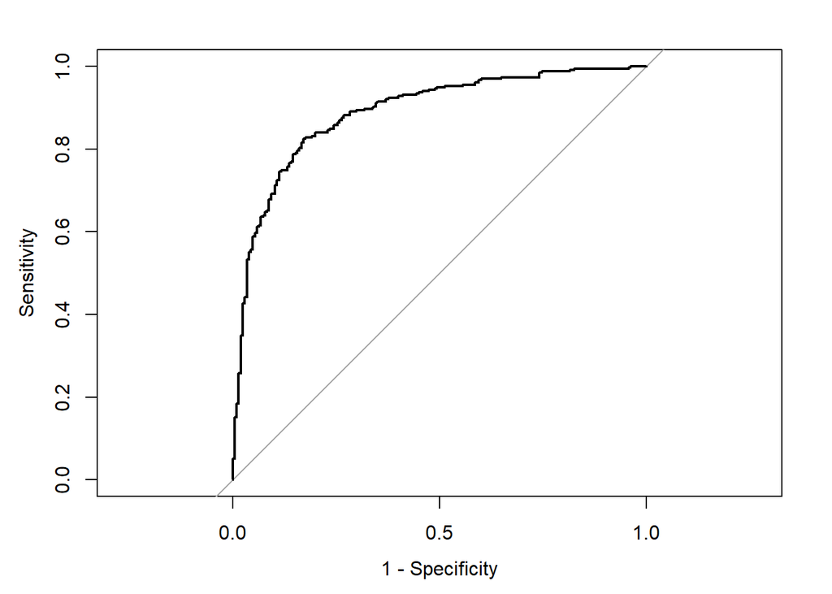

```r
library(pROC)
roc <- roc(test$Purchase, prob$MM, levels = c("MM","CH"))
plot(roc, legacy.axes = T)
```

# 2(d)

We employ the same methods but using QDA instead  
QDA fails if there is rank deficiency, in other words we have columns that  
fully or partially (near fully) explain other columns. This means our  
data has linear dependency or multicollinearity. If we can’t invert a  
matrix then we cannot use qda effectively or at all. Below is what  
would be the qda procedure if there were no multicollinearity.  
However, it will result in rank deficiency and ultimately fail.

```r
# library(caret)
# set.seed(1)
# model <- train(Purchase~., train,
#                method="qda", trControl = tc)
# model
qda.err = "No good" # 1 - model$results[,2]
# prob = predict(model, test, type = "prob")
# pred <- ifelse(prob$MM >= 0.5, "MM", "CH")
# confusionMatrix(table(test$Purchase, pred))
# library(pROC)
# roc <- roc(test$Purchase, prob$MM, levels = c("MM","CH"))
# plot(roc, legacy.axes = T)
```

# 2(e)

We employ the same methods but using KNN, we also use caret  
to find the optimal KNN k value for lowest test error rate

```r
library(caret)
set.seed(1)
model <- train(Purchase~., train,
               method="knn", trControl = tc)
model # optimal k is 5, caret automatically uses this k
```

```
## k-Nearest Neighbors
##
## 535 samples
##  15 predictor
##   2 classes: 'CH', 'MM'
##
## No pre-processing
## Resampling: Cross-Validated (10 fold)
## Summary of sample sizes: 481, 482, 481, 481, 482, 482, ...
## Resampling results across tuning parameters:
##
##   k  Accuracy   Kappa
##   5  0.6895178  0.3432383
##   7  0.6743885  0.3045327
##   9  0.6633124  0.2722348
##
## Accuracy was used to select the optimal model using the largest value.
## The final value used for the model was k = 5.
```

```r
knn.err = 1 - model$results[,2]
prob = predict(model, test, type = "prob")
pred <- ifelse(prob$MM >= 0.5, "MM", "CH")
confusionMatrix(table(test$Purchase, pred))
```

```
## Confusion Matrix and Statistics
##
##     pred
##       CH  MM
##   CH 262  68
##   MM  89 116
##
##                Accuracy : 0.7065
##                  95% CI : (0.666, 0.7448)
##     No Information Rate : 0.6561
##     P-Value [Acc > NIR] : 0.007396
##
##                   Kappa : 0.3669
##  Mcnemar's Test P-Value : 0.110450
##
##             Sensitivity : 0.7464
##             Specificity : 0.6304
##          Pos Pred Value : 0.7939
##          Neg Pred Value : 0.5659
##              Prevalence : 0.6561
##          Detection Rate : 0.4897
##    Detection Prevalence : 0.6168
##       Balanced Accuracy : 0.6884
##
##        'Positive' Class : CH
##
```

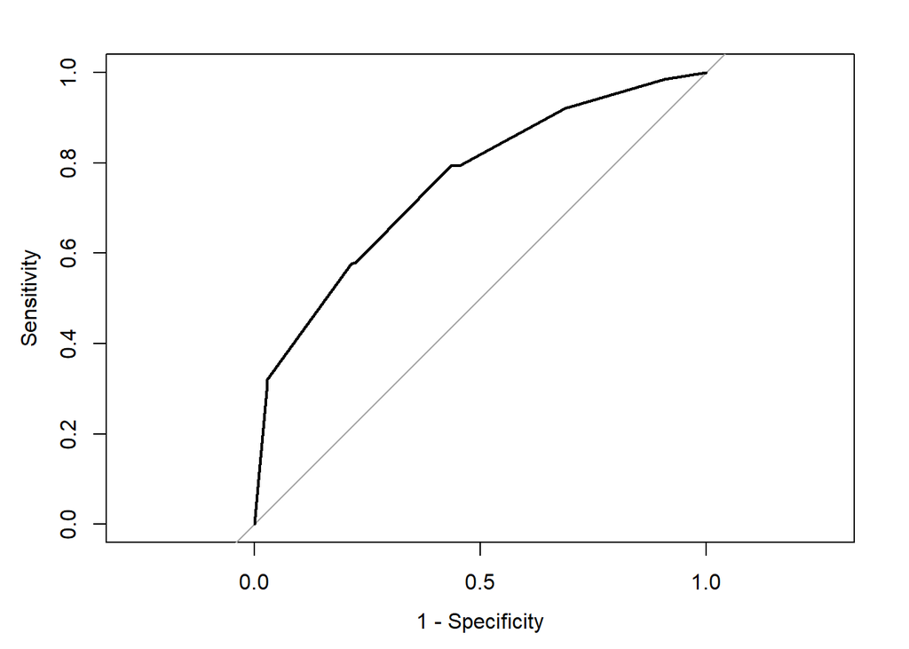

```r
library(pROC)
roc <- roc(test$Purchase, prob$MM, levels = c("MM","CH"))
plot(roc, legacy.axes = T)
```

# 2(f)

Now lets combine all the test error rates together and see which is the lowest  
It seems that lda is our best model for 10 fold CV  
KNN had nearly double of the other models

```r
rbind(glm.err, lda.err, qda.err, knn.er = min(knn.err))
```

```
##         [,1]
## glm.err "0.179559748427673"
## lda.err "0.179489867225716"
## qda.err "No good"
## knn.er  "0.310482180293501"
```

# Question 3(a)

Let us dive into the Auto data from ISLR and use MPG as our response

```r
library(ISLR)
library(leaps)
set.seed(1)
auto = subset(Auto, select = -name)
# eda
str(auto)
```

```
## 'data.frame':    392 obs. of  8 variables:
##  $ mpg         : num  18 15 18 16 17 15 14 14 14 15 ...
##  $ cylinders   : num  8 8 8 8 8 8 8 8 8 8 ...
##  $ displacement: num  307 350 318 304 302 429 454 440 455 390 ...
##  $ horsepower  : num  130 165 150 150 140 198 220 215 225 190 ...
##  $ weight      : num  3504 3693 3436 3433 3449 ...
##  $ acceleration: num  12 11.5 11 12 10.5 10 9 8.5 10 8.5 ...
##  $ year        : num  70 70 70 70 70 70 70 70 70 70 ...
##  $ origin      : num  1 1 1 1 1 1 1 1 1 1 ...
```

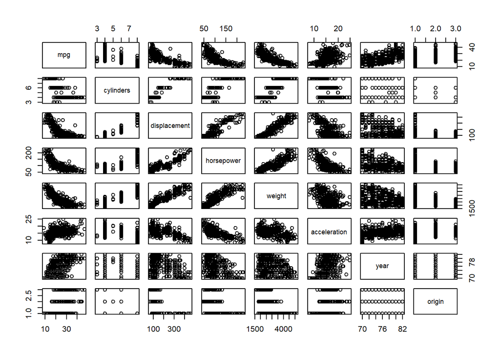

```r
# summary(auto) # nice way to get some quick stats, but messy so I commented
# Just looking at the scatterplots we see that mpg has many trends with others
pairs(subset(auto))
```

```r
cor(auto)
```

```
##                     mpg  cylinders displacement horsepower     weight
## mpg           1.0000000 -0.7776175   -0.8051269 -0.7784268 -0.8322442
## cylinders    -0.7776175  1.0000000    0.9508233  0.8429834  0.8975273
## displacement -0.8051269  0.9508233    1.0000000  0.8972570  0.9329944
## horsepower   -0.7784268  0.8429834    0.8972570  1.0000000  0.8645377
## weight       -0.8322442  0.8975273    0.9329944  0.8645377  1.0000000
## acceleration  0.4233285 -0.5046834   -0.5438005 -0.6891955 -0.4168392
## year          0.5805410 -0.3456474   -0.3698552 -0.4163615 -0.3091199
## origin        0.5652088 -0.5689316   -0.6145351 -0.4551715 -0.5850054
##              acceleration       year     origin
## mpg             0.4233285  0.5805410  0.5652088
## cylinders      -0.5046834 -0.3456474 -0.5689316
## displacement   -0.5438005 -0.3698552 -0.6145351
## horsepower     -0.6891955 -0.4163615 -0.4551715
## weight         -0.4168392 -0.3091199 -0.5850054
## acceleration    1.0000000  0.2903161  0.2127458
## year            0.2903161  1.0000000  0.1815277
## origin          0.2127458  0.1815277  1.0000000
```

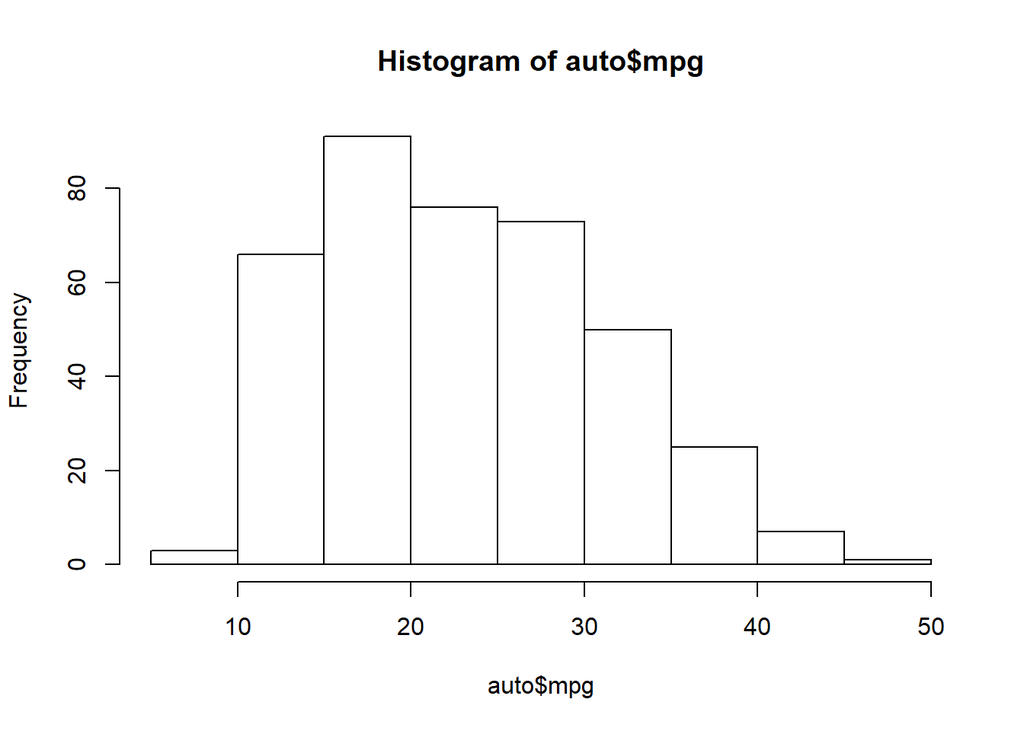

```r
# seems to be right skewed
hist(auto$mpg)
```

```r
# here we look at what would be worthy predictor variables.  However,
# we are using all of them and whittling down with variable selection methods.
```